# Integrando Aplicações utilizando REST com Web API

## Professor Henry Cagnini

### Agenda

- O que é uma API?
  - Web APIs
- HTTP
- O que é REST?
- O que é RESTful?
- SOAP vs REST
- Integrando aplicações com Web API: um exemplo prático
- Exercícios
- Referências

## O que é uma API?

- API, sigla para o termo em inglês *Application Programming Interface*, é um tipo de interface para comunicação entre diferentes entidades
  - Podem ser diferentes softwares, diferentes hardwares, hardware-software, algoritmos dentro de um mesmo software...

## Exemplos de APIs

Quando criamos um gráfico em Python, usando a biblioteca `matplotlib`, esta nos provê uma API -- uma maneira de nos comunicarmos com ela --, sem que contudo saibamos como ela de fato faz para pintar os elementos gráficos na tela

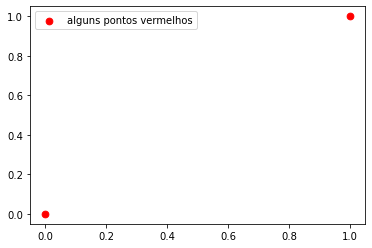

```python
from matplotlib import pyplot as plt

plt.scatter(x=[0, 1], y=[0, 1], c='red', s=45, label='alguns pontos vermelhos')
plt.legend()
plt.show()
```

## O que está acontecendo aqui?

- `plt.scatter` é uma função da API `matplotlib.pyplot`: pinta pontos na tela
- `plt.legend` é outra função, que mostra a legenda dos itens
- `plt.show` mostra os dados

contudo...

- Não sabemos como `matplotlib.pyplot` faz para posicionar os itens na tela
- Nem para escolher o aspect ratio (reparou que o desenho não é quadrado?)
- Muito menos como é feita a seleção dos pixels a serem pintados

## API: características

- Perceba que a API `matplotlib.pyplot` é rodada inteiramente na nossa máquina local: nenhum acesso à Web foi feito
- Portanto, o termo API é abrangente
- É cada vez mais comum que desenvolvedores coloquialmente referenciem **Web APIs** quando estão falando de APIs

## Web APIs

- Uma **Web API** é semelhante à uma API, porém as funcionalidades são oferecidas através de uma rede [de computadores]
- É uma forma de um produtor (servidor) se comunicar com um consumidor (o cliente)
- Um dos métodos de realizar esta comunicação é através do modelo de arquitetura REST, que utiliza o protocolo de comunicação HTTP (*Hypertext Transfer Protocol*)

## HTTP

- Dentro do modelo REST, possui métodos para indicar em que sentido a comunicação está indo: `GET` (recuperando algo) ou `POST` (enviando algo)
- O método `GET`, como o nome sugere, recupera uma informação de um servidor remoto
- No nosso caso, o servidor remoto será nossa Web API
- Exemplo:

```
http://chroniclingamerica.loc.gov/search/pages/results/?format=json&proxtext=fire
```

Estamos:

- enviando para o servidor no endereço `chroniclingamerica.loc.gov`,
- utilizando o protocolo HTTP (`http://`),
- uma requisição para recuperar as informações em formato `json` (`?format=json`),
- E (`&`)
- Todos os textos que possuem o termo *fire* (`proxtext=fire`)

## HTTP

- Para enviar uma informação, utilizaríamos o método `POST`
- As informações não são explícitas na URL (endereço), mas sim no corpo da requisição HTTP
- Menos explícito, mas não mais seguro
  - HTTPS para encriptar os dados

## Mas afinal de contas, o que é REST?

- REST significa *REpresentational State Transfer* em inglês
- É um padrão de desenvolvimento para Web APIs
- Os dois métodos de utilização de HTTP que vimos anteriormente derivam do REST

## O que é REST?

É possível recuperar dados utilizando o método `POST`?

- Tecnicamente, sim!
- Porém não estaríamos seguindo o protocolo REST, que define que `POST` deve ser utilizado para enviar informações
- Também define que `GET` deve ser utilizado para recuperar informações
- Existem outros métodos (também chamados de verbos), como por exemplo:
  - `DELETE` para remover um registro
  - `PUT` para atualizar um registro

## Quais as características do protocolo REST?

- As URLs (*Uniform Resource Locator*), também chamadas de URIs (*Uniform Resource Identifier*), devem ser legíveis

```
http://chroniclingamerica.loc.gov/search/pages/results/?format=json&proxtext=fire
```

- As aplicações são *stateless* (sem estado): ou seja, o servidor (quem provê os dados) não precisa saber o estado do cliente (quem os consome), e vice-versa
  - Independe da troca de mensagens realizada no passado
  - Prioriza troca de *dados* ao invés de troca de *comandos*
  - Os dois lados só precisam saber como se comunicar!
- Essa comunicação é feita através de métodos do HTTP (`GET`, `POST`, `UPDATE`, etc) e, no caso de recuperação/envio de dados, ele é feito utilizando um formato de dados comum
  - JSON, XML, etc

## Quais as características do protocolo REST?

No exemplo anterior, quando usamos

```
http://chroniclingamerica.loc.gov/search/pages/results/?format=json&proxtext=fire
```

Estamos fazendo uma solicitação de dados à um servidor

[O começo d]a resposta que nos foi dada é

```
{
  "totalItems": 7895968,
  "endIndex": 20,
  "startIndex": 1,
  "itemsPerPage": 20,
  "items": [
    {
      "sequence": 37,
      "county": [
        null
      ],
      "edition": null,
      "frequency": "Daily",
      "id": "/lccn/sn83045433/1922-06-11/ed-1/seq-37/",
      "subject": [
        "Washington (D.C.)--fast--(OCoLC)fst01204505",
        "Washington (D.C.)--Newspapers."
```

## Quais as características do protocolo REST?

- Os dados retornados estão em formato JSON, um formato concordado entre o servidor e o cliente
- Foi explicitamente solicitado ao servidor no `GET`
- Provavelmente porque o servidor suporta outros formatos (e.g. XML)

```
{
  "totalItems": 7895968,
  "endIndex": 20,
  "startIndex": 1,
  "itemsPerPage": 20,
  "items": [
    {
      "sequence": 37,
      "county": [
        null
      ],
      "edition": null,
      "frequency": "Daily",
      "id": "/lccn/sn83045433/1922-06-11/ed-1/seq-37/",
      "subject": [
        "Washington (D.C.)--fast--(OCoLC)fst01204505",
        "Washington (D.C.)--Newspapers."
```

## Exemplo de um sistema REST

As redes sociais são um exemplo de sistema que segue o protocolo REST

[figure not shown]

## E o que é RESTful?

- É o nome dado à um sistema que segue o modelo de arquitetura REST!
- Por exemplo, o servidor do exemplo anterior pode ser RESTful

[figure not shown]

## REST vs SOAP

- REST não é o único modelo de arquitetura de Web APIs. Na verdade SOAP (*Simple Object Access Protocol*) é um modelo mais antigo
- Porém perdeu espaço no mercado para o REST!
- Por quê?

## REST vs SOAP

Principais diferenças entre REST e SOAP:

| Característica | SOAP | REST |
| --- | --- | --- |
| Serviço prestado | Serviço e dados | Dados |
| Formato de dados | XML | XML, JSON, YAML |
| Estado | "Stateful" | Stateless |

## Exemplo prático

- Agora que já sabemos todos os conceitos básicos de uma Web API que utiliza REST, vamos montar uma!
- Utilizaremos Python e Flask para esta finalidade
- Flask é um framework para desenvolvimento de Web APIs
- Simples e rápido
- Evitará que tenhamos que entrar em muitos detalhes não pertinentes à esta aula

[figure not shown]

## Exemplo prático

- Precisaremos instalar o [Python Anaconda](https://www.anaconda.com/products/individual)
- Disponível para todos os sistemas operacionais
- Oferece um poderoso gerenciador de pacotes: `conda`

## Instalando o ambiente

- Uma vez instalado, abra uma janela da linha de comando no seu sistema operacional
- Navegue até a pasta onde você baixou o material desta aula
- Digite os seguintes comandos:

```
conda create --name apitest python=3.9.2
conda activate apitest  # ativa ambiente virtual
conda install --file requirements.txt --yes
```

## Aplicação

- Neste exemplo, estamos interessados em criar uma Web API para retornar aos usuários o cardápio de um restaurante
- Utilizaremos tabelas do pandas para armazenar os dados
  - Poderíamos utilizar o sqlite3, mas com o pandas faremos com que os dados sejam visíveis no console
- Os dados são referentes a uma pizzaria

[figure not shown]

## Criando as tabelas de dados

```python
import pandas as pd
from IPython.display import display

produtos = pd.DataFrame(
    data=[
        ['refrigerante A', 'bebida', 5],
        ['refrigerante B', 'bebida', 7],
        ['pizza pequena', 'pizza', 30],
        ['pizza média', 'pizza', 40],
        ['pizza grande', 'pizza', 50],
        ['bombom', 'doce', 1]
    ],
    columns=['nome', 'tipo', 'valor']
)

display(produtos)
```

|  | nome | tipo | valor |
| --- | --- | --- | --- |
| 0 | refrigerante A | bebida | 5 |
| 1 | refrigerante B | bebida | 7 |
| 2 | pizza pequena | pizza | 30 |
| 3 | pizza média | pizza | 40 |
| 4 | pizza grande | pizza | 50 |
| 5 | bombom | doce | 1 |

## Criando as tabelas de dados

```python
sabores = pd.DataFrame(
    data=[
        ['calabresa'],
        ['portuguesa'],
        ['chocolate']
    ],
    columns=['nome']
)

display(sabores)
```

|  | nome |
| --- | --- |
| 0 | calabresa |
| 1 | portuguesa |
| 2 | chocolate |

## Criando as tabelas de dados

```python
produto_para_sabor_index = pd.MultiIndex.from_tuples([
        (2, 2),
        (3, 0),
        (3, 1),
        (4, 0),
        (4, 1)
    ], names=['id_produto', 'id_sabor'])

produto_para_sabor = pd.DataFrame(
    index=produto_para_sabor_index
)

display(produto_para_sabor)
```

| id_produto | id_sabor |
| --- | --- |
| 2 | 2 |
| 3 | 0 |
|  | 1 |
| 4 | 0 |
|  | 1 |

## Demonstração puramente com tabelas

Queremos saber quais sabores vão em quais pizzas. Vamos usar os operadores do pandas para visualizar essa informação:

```python
first_step = produto_para_sabor.join(produtos, on='id_produto', how='left')
second_step = first_step.join(sabores, on='id_sabor', how='inner', lsuffix='_produto', rsuffix='_sabor')

display(second_step)
```

| id_produto | id_sabor | nome_produto | tipo | valor | nome_sabor |
| --- | --- | --- | --- | --- | --- |
| 2 | 2 | pizza pequena | pizza | 30 | chocolate |
| 3 | 0 | pizza média | pizza | 40 | calabresa |
| 4 | 0 | pizza grande | pizza | 50 | calabresa |
| 3 | 1 | pizza média | pizza | 40 | portuguesa |
| 4 | 1 | pizza grande | pizza | 50 | portuguesa |

## Montando o exemplo com Flask

Agora vamos começar a construir nossa Web API com Flask

- Crie um arquivo `main.py`, escreva o seguinte código nele, e o execute na linha de comando com `python main.py`

```
import flask
from flask import request, jsonify

app = flask.Flask(__name__)
app.config["DEBUG"] = True

app.run()
```

### O que está acontecendo aqui?

- Estamos importando a biblioteca flask, junto com algumas utilidades
- Estamos criando um novo servidor com `app = flask.Flask(__name__)`
- O modo de debugging de flask está ativado: `app.config["DEBUG"] = True`
- Estamos iniciando este servidor com `app.run()`

## Montando o exemplo com Flask

- Precisamos agora conectar a Web API ao nosso banco de dados (que aqui está representado por três tabelas do pandas)
- Pare de executar a Web API, iniciada anteriormente com `python main.py`, e edite o arquivo de código-fonte
- Crie uma callback para quando o recurso solicitado não for encontrado no servidor

```
@app.errorhandler(404)
def page_not_found(e):
    return "<h1>404</h1><p>O recurso solicitado não pôde ser encontrado.</p>", 404
```

O que está acontecendo aqui?

- Estamos fazendo uso de um *decorator*, uma funcionalidade da linguagem de programação Python
  - O decorator em questão é `@app.errorhandler`
- Ele registra na biblioteca Flask que queremos usar a função `page_not_found` quando o usuário requisitar uma página indisponível do lado do servidor
- Essa função então será chamada toda vez que um erro 404 for gerado

## Montando o exemplo com Flask

Cria uma callback para quando o usuário acessa o diretório raiz do servidor

```
@app.route('/', methods=['GET'])
def home():
    return '''<h1>Pizzaria do Henry</h1>
<p>Bem vindo à pizzaria do Henry! Sente-se e sinta-se a vontade!</p>'''
```

O que está acontecendo aqui?

- Estamos usando outro *decorator*, `@app.route`, para registrar no Flask que a função `home` deve ser chamada quando a página solicitada for a raiz do nosso servidor (por exemplo, `http://localhost:5000/`)
- Estamos também dizendo ao *decorator* que a forma de se chegar até essa função é com o método `GET`

## Montando o exemplo com Flask

Cria uma callback para quando o usuário requisita todos os produtos da base

```
@app.route('/api/v1/recursos/produtos/all', methods=['GET'])
def produtos_all():
    return jsonify(produtos.to_json())
```

Cria uma callback para quando o usuário requisita todos os sabores da base

```
@app.route('/api/v1/recursos/sabores/all', methods=['GET'])
def sabores_all():
    return jsonify(sabores.to_json())
```

## Montando o exemplo com Flask

- Cria uma callback para consultas customizadas em produtos, com base no id (que no nosso exemplo é o índice do `pandas.DataFrame`), ou no tipo de produto
- Retorna um erro 404 caso o usuário não passe nenhuma informação na consulta

```
@app.route('/api/v1/recursos/produtos', methods=['GET'])
def api_filter():
    query_parameters = request.args

    some_id = query_parameters.get('id')
    tipo = query_parameters.get('tipo')

    res = produtos

    if some_id:
        res = produtos.loc[int(some_id)]
    if tipo:
        res = res.loc[res['tipo'] == tipo]
    if (not some_id) and (not tipo):
        return page_not_found(404)

    return jsonify(res.to_json())
```

## Demonstração do código executando

[figure not shown]

## Conclusão

- Pronto! Conseguimos iniciar uma Web API com Flask
- Fizemos apenas o lado do servidor, e "simulamos" um cliente através de consultas pelo navegador
- Nada nos impede agora de fazer um script que aja realmente como cliente:

```
import urllib.request as request
import json

with request.urlopen('http://localhost:5000/api/v1/recursos/sabores/all') as response:
    source = response.read()
    data = json.loads(source)
    print(data)
```

Saída:

```
{"nome":{"0":"calabresa","1":"portuguesa","2":"chocolate"}}
```

## Exercícios

1. Modifique o exemplo fornecido para incluir uma callback que relacione sabores às pizzas
2. Faça uma callback para fazer consultas customizadas para sabores
3. Adicione uma terceira tabela, ingredientes, e crie a tabela pivô, sabores_para_ingredientes
4. Crie uma callback para consultar os ingredientes por id e nome
5. Crie uma callback para consultar a relação de ingredientes para sabores

## Referências

- [What is REST?](https://www.codecademy.com/articles/what-is-rest)
- [SOAP vs. REST](https://stackify.com/soap-vs-rest/)
- [REST: princípios e boas práticas](https://blog.caelum.com.br/rest-principios-e-boas-praticas/)
- [Creating Web APIs with Python and Flask](https://programminghistorian.org/en/lessons/creating-apis-with-python-and-flask)
- [HTTP: GET e POST - Conheça as diferenças entre os métodos](https://www.alura.com.br/artigos/diferencas-entre-get-e-post?gclid=CjwKCAjwu5CDBhB9EiwA0w6sLR5KkgWB_bsmlPAazxcYIHsGTbjF-M897SB5O-1GWm2L48p4mGmFnRoClFYQAvD_BwE)